# Chapter_3_Matrices_Assignment

Damilare Olaleye

02/09/2020

#### Defining a Matrix

#### Question 1

The wikipedia entry https://en.wikipedia.org/wiki/Magic_square describes a magic square where the sum of integers along each row, along each column, and the diagonal is the same number.  
This page shows a 3 by 3 magic square – put the values of this square in a matrix A with 3 rows and 3 columns.

```r
M <-c(2,7,6,9,5,1,4,3,8)
A <- matrix(M,nrow= 3, ncol = 3, byrow = T)
print(A)
```

```
##      [,1] [,2] [,3]
## [1,]    2    7    6
## [2,]    9    5    1
## [3,]    4    3    8
```

Display the 2nd row of your matrix, and the 3rd column of the matrix.

```r
A[2, ,drop=F]
```

```
##      [,1] [,2] [,3]
## [1,]    9    5    1
```

```r
A[, 3,drop=F]
```

```
##      [,1]
## [1,]    6
## [2,]    1
## [3,]    8
```

#### Matrix Operations

#### Question 2

Multiply each entry of your matrix A by 3 and add 4 to the result.

```r
(A * 3) + 4
```

```
##      [,1] [,2] [,3]
## [1,]   10   25   22
## [2,]   31   19    7
## [3,]   16   13   28
```

What happens if you type A * A? It multiply itself through an entry wise multiplication

```r
A * A
```

```
##      [,1] [,2] [,3]
## [1,]    4   49   36
## [2,]   81   25    1
## [3,]   16    9   64
```

Suppose, the matrix B is defined as follows. Can you add matrices A and B? If not, can you redefine the matrix B so that you can add A and B?

```r
B <- matrix(1:12, 3, 4)
```

No, we cannot add matrices A and B, but after redefing matrix B we should be able to add A and B, as shown below:

```r
A + B[1,3]
```

```
##      [,1] [,2] [,3]
## [1,]    9   14   13
## [2,]   16   12    8
## [3,]   11   10   15
```

#### Multiplying matrices

#### Question 3

Below I have defined three matrices, m1, m2, and m3.

```r
m1 <- matrix(1:4, 2, 2)
m2 <- matrix(c(2, 1, 3, 5, 2, 1), 2, 3)
m3 <- matrix(1:3, 3, 1)
```

Without doing any R work, can you do the following matrix operations?

m1 %*% m2 = yes… using linear algebra logic M1 = 2 X 2, and M2 = 2 X 3… therefore, we since the 2nd col of m1 match the first col of row 1, the operations should work

m2 %*% m1 = no… using linear algebra logic M1 = 2 X 2, and M2 = 2 X 3… therefore, we since the 2nd col of m2 does not match the first col of m1, the operations will not work.

m2 %*% m3 = yes… using linear algebra logic M3 = 3 X 1, and M2 = 2 X 3… therefore, we since the 2nd col of m2 match the first col of m3, the operations will work

Check to see if your answers are correct.

```r
m1 %*% m2
```

```
##      [,1] [,2] [,3]
## [1,]    5   18    5
## [2,]    8   26    8
```

```r
#m2 %*% m1
```

```r
#m3 %*% m2
```

```r
m2 %*% m3
```

```
##      [,1]
## [1,]   14
## [2,]   14
```

#### Filtering on Matrices

#### Question 4

Explain in words what these filtering operations mean.

```r
A[A > 3]
```

```
## [1] 9 4 7 5 6 8
```

To check if A is greater than 3, display numbers greater than 3.

```
A[A[1, ] > 3, ]
```

this extract the second and third row of the matrices

```
A[ , A[, 2] == 5]
```

#### Using apply on Marathon data

Here you are reading in some 2011 Boston Marathon data.

```r
library(tidyverse)
boston <- read_csv("http://www-math.bgsu.edu/~albert/3440/marathon2011.csv")
```

Extract the split times from the data frame (remove variables Age and Gender1F2M):

```r
split <- as.matrix(boston[, -c(1:2)])
```

#### Question 5

Using the apply function compute the mean time of each split (K0.5, K5.10, etc). Graph these means.

```r
k<-apply(split, 2, mean)
k
```

```
##     K0.5    K5.10   K10.15   K15.20   K20.25   K25.30   K30.35   K35.40
## 25.36734 25.40663 25.53365 26.26821 26.81300 28.34516 29.54679 29.70891
```

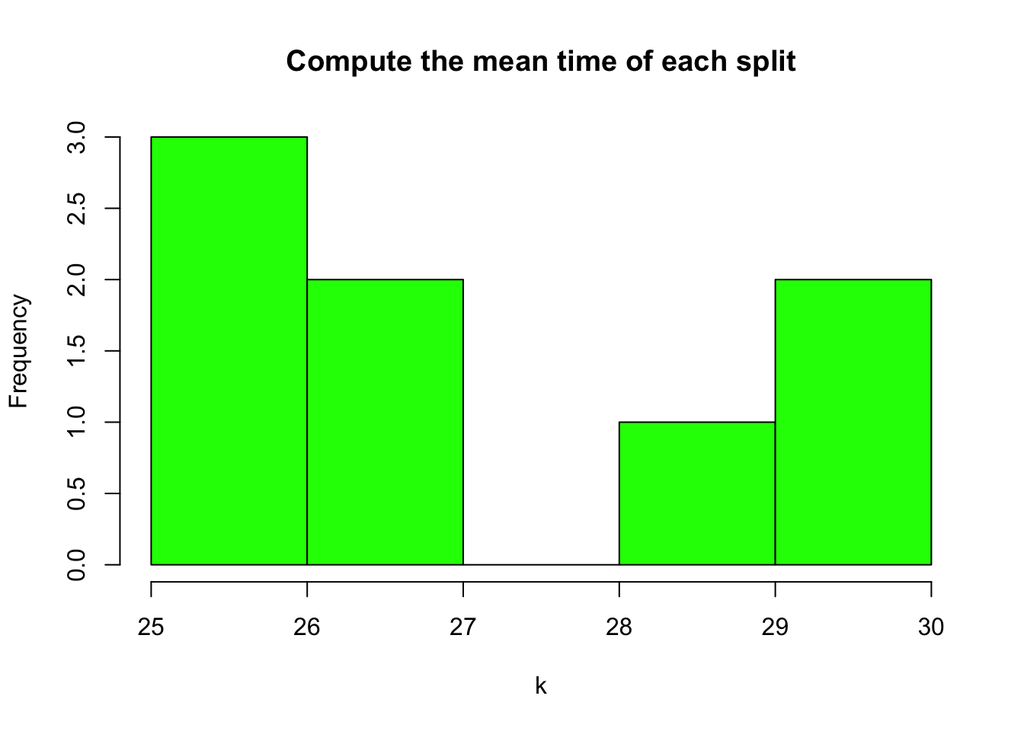

```r
hist(k, col="Green", main = "Compute the mean time of each split")
```

Using the apply function compute the max time of each split (K0.5, K5.10, etc). Graph these means.

```r
k<-apply(split, 2, (max))
k
```

```
##   K0.5  K5.10 K10.15 K15.20 K20.25 K25.30 K30.35 K35.40
##  73.52  68.22  57.28 102.97  97.58  89.50 155.75  86.72
```

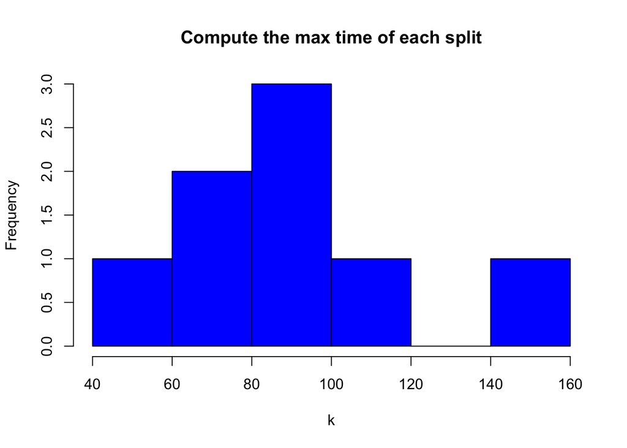

```r
hist(k, col="blue", main = "Compute the max time of each split")
```

Find the index of the max split time for each runner. Graph these index files?

```r
k<-apply(split, 1, which.max)
k
```

[output not shown]

[output cut: 689 more lines]

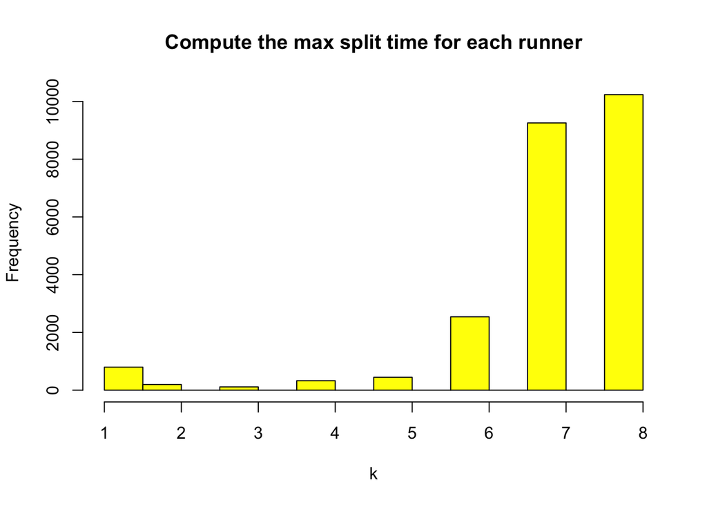

```r
hist(k, col="yellow", main = "Compute the max split time for each runner")
```

What if you apply with a function that has two outputs? To check, the range function has two outputs (the min and max). Apply the range function for each split.

```r
apply(split, 2, function(x) range(min(x), max(x)))
```

```
##       K0.5 K5.10 K10.15 K15.20 K20.25 K25.30 K30.35 K35.40
## [1,] 14.48 12.41  12.41  12.41  12.41  12.41  12.41  11.44
## [2,] 73.52 68.22  57.28 102.97  97.58  89.50 155.75  86.72
```